[figure not shown]

# Prepare the data

## Load

```python
df = pd.read_csv("../dsg17-final/input/train.csv", sep = ";", decimal=".")
test = pd.read_csv("../dsg17-final/input/test.csv")
```

```python
df.head()
```

|  | ID | First_MAD | SalOrg | DC | Ship_To | ordre | Plant | Material | ItemCat | OrderQty | LT | LogABC | MOQ | ROP | SafetyStk | PL | MktABC | SubFct | Gross_Weight | Length | Width | Height | Volume | Gamma | Manufacturer | Business | Month | CBO_CBO_Qty_Shortage | Age_ZN_ZI_years | … |
| --- | --- | --- | --- | --- | --- | --- | --- | --- | --- | --- | --- | --- | --- | --- | --- | --- | --- | --- | --- | --- | --- | --- | --- | --- | --- | --- | --- | --- | --- | --- |
| 0 | 2724174 | 2014-09-12 | yqSu | TUiR | MsHvUF | ggT8Bq | vP6T | iR1zr2 | lvOi | 1 | 28.0 | Nc4e | 72.0 | 0.0 | 21.0 | NmYB | 9rfJ | PjXe | 0.006299 | 0.643863 | 2.148148 | 0.693069 | 0.000480 | syni | 1nVy21 | 32af | 2014-09 | NaN | NaN | … |
| 1 | 2325939 | 2016-02-12 | yqSu | csdY | BA5kLC | AIZGVy | vP6T | mD2b7j | lvOi | 10 | 35.0 | hfuf | 300.0 | 0.0 | 87.0 | c2Z5 | vegq | PjXe | 0.000693 | 0.281690 | 0.296296 | 3.613861 | 0.000151 | syni | 1nVy21 | otZd | 2016-02 | 0.0 | NaN | … |
| 2 | 1836800 | 2013-05-24 | U12J | TUiR | MBZhLQ | 8Z4g83 | Cisr | AjywTn | lvOi | 2 | 28.0 | Nc4e | 12.0 | 0.0 | 69.0 | ss6l | vegq | PjXe | 0.038961 | 1.529175 | 2.518519 | 0.653465 | 0.001261 | MYF4 | o86vTw | 32af | 2013-05 | NaN | 2.493151 | … |
| 3 | 2820654 | 2012-07-12 | yqSu | csdY | 9Co4iE | RNuiEu | vP6T | DPiXfc | lvOi | 10 | 35.0 | Nc4e | 450.0 | 0.0 | 148.0 | c2Z5 | vegq | PjXe | 0.000682 | 0.241449 | 4.814815 | 0.247525 | 0.000144 | syni | 1nVy21 | otZd | 2012-07 | NaN | NaN | … |
| 4 | 5579286 | 2012-02-29 | OQfZ | TUiR | 88lPvN | KPTgL7 | 9O7Z | tOsuQV | lvOi | 6 | 28.0 | Nc4e | 460.0 | 0.0 | 500.0 | c2Z5 | 9rfJ | PjXe | 0.000693 | 0.261569 | 4.481481 | 0.173267 | 0.000100 | 9AXw | OEScPd | otZd | 2012-02 | NaN | NaN | … |

```python
df.shape
```

```
(5595701, 41)
```

```python
df.describe()
```

|  | ID | OrderQty | LT | MOQ | ROP | SafetyStk | Gross_Weight | Length | Width | Height | Volume | CBO_CBO_Qty_Shortage | Age_ZN_ZI_years | Comp_reference_number | Name_Of_Competitor | COMP_PRICE_MIN | COMP_PRICE_AVG | COMP_PRICE_MAX | PRICE | NEAREST_COMP_PRICE_MIN | NEAREST_COMP_PRICE_MAX |
| --- | --- | --- | --- | --- | --- | --- | --- | --- | --- | --- | --- | --- | --- | --- | --- | --- | --- | --- | --- | --- | --- |
| count | 5.595701e+06 | 5.595701e+06 | 5.595700e+06 | 5.595700e+06 | 5.595700e+06 | 5.595700e+06 | 5.595701e+06 | 5.595701e+06 | 5.595701e+06 | 5.595701e+06 | 5.595701e+06 | 2.724594e+06 | 1.853763e+06 | 5.258191e+06 | 5.258191e+06 | 2.121384e+06 | 2.121384e+06 | 2.121384e+06 | 2.388870e+06 | 2.121384e+06 | 2.121384e+06 |
| mean | 3.646187e+06 | 7.461934e+00 | 3.370401e+01 | 1.403106e+02 | 3.734635e+00 | 2.413586e+02 | 8.011129e-03 | 9.517893e-01 | 2.100058e+00 | 7.691710e-01 | 7.546465e-04 | 5.868896e-01 | 3.458818e+00 | 5.777209e-01 | 5.057990e-01 | 2.035065e+02 | 2.119079e+02 | 2.201040e+02 | 2.152748e+02 | 2.118683e+02 | 2.119443e+02 |
| std | 2.106117e+06 | 4.343582e+01 | 2.006159e+01 | 2.398007e+02 | 3.561514e+01 | 6.007280e+02 | 1.985787e-02 | 7.908497e-01 | 1.693008e+00 | 8.834940e-01 | 4.860782e-03 | 1.590793e+01 | 1.998652e+00 | 8.493506e-01 | 6.783801e-01 | 1.963082e+02 | 2.054457e+02 | 2.170663e+02 | 2.007371e+02 | 2.079232e+02 | 2.081222e+02 |
| min | 2.000000e+00 | 1.000000e+00 | 0.000000e+00 | 0.000000e+00 | 0.000000e+00 | 0.000000e+00 | 0.000000e+00 | 0.000000e+00 | 0.000000e+00 | 0.000000e+00 | 0.000000e+00 | 0.000000e+00 | 0.000000e+00 | 0.000000e+00 | 0.000000e+00 | 3.500000e+00 | 3.500000e+00 | 3.500000e+00 | 3.570000e+00 | 3.500000e+00 | 3.500000e+00 |
| 25% | 1.822350e+06 | 1.000000e+00 | 2.800000e+01 | 7.000000e+00 | 0.000000e+00 | 8.000000e+00 | 6.277056e-04 | 2.816901e-01 | 7.037037e-01 | 2.772277e-01 | 9.982992e-05 | 0.000000e+00 | 1.871233e+00 | 0.000000e+00 | 0.000000e+00 | 4.800000e+01 | 4.840000e+01 | 4.920000e+01 | 5.625000e+01 | 4.900000e+01 | 4.900000e+01 |
| 50% | 3.647149e+06 | 1.000000e+00 | 3.500000e+01 | 2.700000e+01 | 0.000000e+00 | 4.400000e+01 | 4.186147e-03 | 7.444668e-01 | 1.962963e+00 | 4.455446e-01 | 4.053095e-04 | 0.000000e+00 | 3.273973e+00 | 0.000000e+00 | 0.000000e+00 | 1.662300e+02 | 1.732500e+02 | 1.792000e+02 | 1.728900e+02 | 1.716260e+02 | 1.716260e+02 |
| 75% | 5.474079e+06 | 4.000000e+00 | 3.500000e+01 | 1.750000e+02 | 0.000000e+00 | 1.960000e+02 | 1.106061e-02 | 1.287726e+00 | 2.518519e+00 | 8.415842e-01 | 6.335872e-04 | 0.000000e+00 | 4.846575e+00 | 1.000000e+00 | 1.000000e+00 | 2.697500e+02 | 2.811120e+02 | 2.918585e+02 | 2.839000e+02 | 2.772000e+02 | 2.772000e+02 |
| max | 7.292398e+06 | 6.560000e+03 | 3.650000e+02 | 4.800000e+03 | 2.800000e+03 | 8.000000e+03 | 1.000000e+01 | 1.000000e+01 | 1.000000e+01 | 1.000000e+01 | 1.000000e+01 | 5.525000e+03 | 9.495890e+00 | 9.000000e+00 | 4.000000e+00 | 2.014110e+03 | 2.014110e+03 | 2.014110e+03 | 2.035000e+03 | 2.014110e+03 | 2.014110e+03 |

## Convert the date into datetime format

```python
df['First_MAD'] = pd.to_datetime(df['First_MAD'])
df["year"] = df["First_MAD"].dt.year
df["month"] = df["First_MAD"].dt.month
```

## Transform the data into monthly time series

### Aggregated time serie

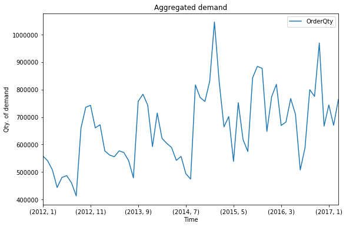

```python
fig, ax = plt.subplots(figsize=(10, 5))
df[['year', 'month', 'OrderQty']].groupby(['year', 'month']).sum().plot(y="OrderQty", ax=ax)
ax.set_title("Aggregated demand")
ax.set_ylabel('Qty. of demand')
ax.set_xlabel('Time');
```

### By SalOrg-Material

```python
gp_data = df[['Material','SalOrg','OrderQty','First_MAD', 'year', 'month']].\
    groupby(['SalOrg', 'Material', 'year', 'month'])
df2 = gp_data.sum().reset_index()
df2.head()
```

|  | SalOrg | Material | year | month | OrderQty |
| --- | --- | --- | --- | --- | --- |
| 0 | 97LK | 00IYcj | 2012 | 5 | 2 |
| 1 | 97LK | 00IYcj | 2012 | 6 | 13 |
| 2 | 97LK | 00IYcj | 2012 | 7 | 1 |
| 3 | 97LK | 00IYcj | 2012 | 9 | 30 |
| 4 | 97LK | 00IYcj | 2012 | 11 | 1 |

We use the `pivot_table` function to represent the data in terms of time series:

```python
df3 = df2.pivot_table(index=['SalOrg', 'Material'], columns=["year", "month"]).fillna(0)
df3.head()
```

| SalOrg | year month Material | OrderQty 2012 1 | OrderQty 2012 2 | OrderQty 2012 3 | OrderQty 2012 4 | OrderQty 2012 5 | OrderQty 2012 6 | OrderQty 2012 7 | OrderQty 2012 8 | OrderQty 2012 9 | OrderQty 2012 10 | OrderQty 2012 11 | OrderQty 2012 12 | OrderQty 2013 1 | OrderQty 2013 2 | OrderQty 2013 3 | OrderQty 2013 4 | OrderQty 2013 5 | OrderQty 2013 6 | OrderQty 2013 7 | OrderQty 2013 8 | OrderQty 2013 9 | OrderQty 2013 10 | OrderQty 2013 11 | OrderQty 2013 12 | OrderQty 2014 1 | OrderQty 2014 2 | OrderQty 2014 3 | OrderQty 2014 4 | … |
| --- | --- | --- | --- | --- | --- | --- | --- | --- | --- | --- | --- | --- | --- | --- | --- | --- | --- | --- | --- | --- | --- | --- | --- | --- | --- | --- | --- | --- | --- | --- |
| 97LK | 00IYcj | 0.0 | 0.0 | 0.0 | 0.0 | 2.0 | 13.0 | 1.0 | 0.0 | 30.0 | 0.0 | 1.0 | 4.0 | 16.0 | 15.0 | 7.0 | 15.0 | 4.0 | 7.0 | 3.0 | 2.0 | 3.0 | 10.0 | 25.0 | 14.0 | 18.0 | 7.0 | 7.0 | 6.0 | … |
|  | 00MFcK | 0.0 | 1.0 | 1.0 | 1.0 | 0.0 | 0.0 | 4.0 | 0.0 | 0.0 | 0.0 | 0.0 | 0.0 | 0.0 | 0.0 | 0.0 | 0.0 | 0.0 | 0.0 | 1.0 | 1.0 | 0.0 | 1.0 | 1.0 | 0.0 | 1.0 | 1.0 | 1.0 | 1.0 | … |
|  | 00Ok8y | 5.0 | 2.0 | 2.0 | 7.0 | 0.0 | 2.0 | 4.0 | 0.0 | 0.0 | 0.0 | 0.0 | 0.0 | 2.0 | 0.0 | 2.0 | 4.0 | 4.0 | 3.0 | 1.0 | 0.0 | 0.0 | 1.0 | 0.0 | 0.0 | 0.0 | 0.0 | 0.0 | 0.0 | … |
|  | 00W03x | 0.0 | 0.0 | 0.0 | 0.0 | 0.0 | 0.0 | 0.0 | 0.0 | 0.0 | 0.0 | 0.0 | 0.0 | 0.0 | 0.0 | 0.0 | 0.0 | 0.0 | 0.0 | 0.0 | 0.0 | 0.0 | 0.0 | 0.0 | 0.0 | 0.0 | 0.0 | 0.0 | 0.0 | … |
|  | 00lqzT | 2.0 | 2.0 | 1.0 | 0.0 | 0.0 | 0.0 | 1.0 | 0.0 | 1.0 | 0.0 | 0.0 | 0.0 | 1.0 | 1.0 | 0.0 | 1.0 | 0.0 | 0.0 | 0.0 | 0.0 | 1.0 | 1.0 | 3.0 | 2.0 | 0.0 | 1.0 | 1.0 | 1.0 | … |

```python
df3.shape
```

```
(38676, 63)
```

```python
df3.columns = list(range(63))
df3 = df3.reset_index()
df3.head(10)
```

|  | SalOrg | Material | 0 | 1 | 2 | 3 | 4 | 5 | 6 | 7 | 8 | 9 | 10 | 11 | 12 | 13 | 14 | 15 | 16 | 17 | 18 | 19 | 20 | 21 | 22 | 23 | 24 | 25 | 26 | … |
| --- | --- | --- | --- | --- | --- | --- | --- | --- | --- | --- | --- | --- | --- | --- | --- | --- | --- | --- | --- | --- | --- | --- | --- | --- | --- | --- | --- | --- | --- | --- |
| 0 | 97LK | 00IYcj | 0.0 | 0.0 | 0.0 | 0.0 | 2.0 | 13.0 | 1.0 | 0.0 | 30.0 | 0.0 | 1.0 | 4.0 | 16.0 | 15.0 | 7.0 | 15.0 | 4.0 | 7.0 | 3.0 | 2.0 | 3.0 | 10.0 | 25.0 | 14.0 | 18.0 | 7.0 | 7.0 | … |
| 1 | 97LK | 00MFcK | 0.0 | 1.0 | 1.0 | 1.0 | 0.0 | 0.0 | 4.0 | 0.0 | 0.0 | 0.0 | 0.0 | 0.0 | 0.0 | 0.0 | 0.0 | 0.0 | 0.0 | 0.0 | 1.0 | 1.0 | 0.0 | 1.0 | 1.0 | 0.0 | 1.0 | 1.0 | 1.0 | … |
| 2 | 97LK | 00Ok8y | 5.0 | 2.0 | 2.0 | 7.0 | 0.0 | 2.0 | 4.0 | 0.0 | 0.0 | 0.0 | 0.0 | 0.0 | 2.0 | 0.0 | 2.0 | 4.0 | 4.0 | 3.0 | 1.0 | 0.0 | 0.0 | 1.0 | 0.0 | 0.0 | 0.0 | 0.0 | 0.0 | … |
| 3 | 97LK | 00W03x | 0.0 | 0.0 | 0.0 | 0.0 | 0.0 | 0.0 | 0.0 | 0.0 | 0.0 | 0.0 | 0.0 | 0.0 | 0.0 | 0.0 | 0.0 | 0.0 | 0.0 | 0.0 | 0.0 | 0.0 | 0.0 | 0.0 | 0.0 | 0.0 | 0.0 | 0.0 | 0.0 | … |
| 4 | 97LK | 00lqzT | 2.0 | 2.0 | 1.0 | 0.0 | 0.0 | 0.0 | 1.0 | 0.0 | 1.0 | 0.0 | 0.0 | 0.0 | 1.0 | 1.0 | 0.0 | 1.0 | 0.0 | 0.0 | 0.0 | 0.0 | 1.0 | 1.0 | 3.0 | 2.0 | 0.0 | 1.0 | 1.0 | … |
| 5 | 97LK | 00mt9e | 3.0 | 2.0 | 1.0 | 1.0 | 2.0 | 6.0 | 3.0 | 6.0 | 5.0 | 0.0 | 11.0 | 8.0 | 6.0 | 10.0 | 2.0 | 3.0 | 2.0 | 0.0 | 15.0 | 2.0 | 2.0 | 2.0 | 1.0 | 3.0 | 1.0 | 6.0 | 6.0 | … |
| 6 | 97LK | 02QhQT | 0.0 | 0.0 | 2.0 | 0.0 | 0.0 | 0.0 | 0.0 | 0.0 | 0.0 | 4.0 | 0.0 | 0.0 | 0.0 | 1.0 | 0.0 | 0.0 | 0.0 | 0.0 | 0.0 | 0.0 | 0.0 | 0.0 | 1.0 | 0.0 | 0.0 | 0.0 | 0.0 | … |
| 7 | 97LK | 02jRc8 | 0.0 | 1.0 | 0.0 | 0.0 | 0.0 | 18.0 | 0.0 | 0.0 | 0.0 | 0.0 | 0.0 | 0.0 | 0.0 | 0.0 | 0.0 | 0.0 | 0.0 | 0.0 | 0.0 | 0.0 | 0.0 | 0.0 | 0.0 | 0.0 | 0.0 | 0.0 | 0.0 | … |
| 8 | 97LK | 0355Np | 0.0 | 0.0 | 0.0 | 0.0 | 1.0 | 2.0 | 2.0 | 0.0 | 0.0 | 0.0 | 1.0 | 0.0 | 1.0 | 0.0 | 7.0 | 6.0 | 0.0 | 0.0 | 0.0 | 0.0 | 10.0 | 3.0 | 0.0 | 1.0 | 0.0 | 2.0 | 7.0 | … |
| 9 | 97LK | 03GYN7 | 0.0 | 0.0 | 0.0 | 0.0 | 0.0 | 0.0 | 0.0 | 0.0 | 0.0 | 0.0 | 0.0 | 0.0 | 0.0 | 0.0 | 0.0 | 0.0 | 0.0 | 0.0 | 0.0 | 0.0 | 0.0 | 0.0 | 0.0 | 0.0 | 0.0 | 0.0 | 0.0 | … |

`df3` dataset contains the time serie historic for each pair of SalOrg & Material (38676 pairs in total).

Here are the plots of the 6 first time series of the dataset:

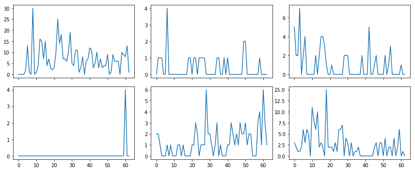

```python
n_col, n_row = 3, 2
fig, axes = plt.subplots(n_row, n_col, sharex=True, figsize=(4*n_col, 2.5*n_row))
k = 0
for i in range(n_row):
    for j in range(n_col):
        ax = axes[i, j]
        ax.plot(df3.iloc[k, 2:].values)
        ax.axis('tight')
        k += 1
fig.tight_layout()
```

# Simpler is better

## Feature engineering

The following `make_feature` function takes a dataset of time series, like `df3`, and build many features per time serie:

- mean/median/std over the last `nb_last_month`
- last months quantity of demand
- number of months since the first/last demand
- mean/median/std over the months between first & last demand
- mean/median/std since the first demand

```
def make_feature(data, nb_last_month):
    """Creates new features from date windows.

    Parameters
    ----------
    data : dataframe,
        The data obviously.
    nb_last_month : list,
        The numbers of months to test.
    """
    data2 = data.copy()
    for i in nb_last_month:
        data2["last_months_mean_" + str(i)] = data.iloc[:,(data.shape[1]-i):(data.shape[1])].mean(axis = 1)
        data2["last_months_std_" + str(i)] = data.iloc[:,(data.shape[1]-i):(data.shape[1])].std(axis = 1)
        data2["last_months_median_" + str(i)] = data.iloc[:,(data.shape[1]-i):(data.shape[1])].median(axis = 1)
    ...
```

As a first step, we build `X_train` based on the month 0 to 60, `y_train` based on the month 61, `X_test_local` based on the months 0 to 61, and `y_test_local` based on the month 62.

This means we compute our validation scores based on the data for march 2017.

[figure not shown]

```python
X_train = make_feature(data= df3[list(range(0,61))], nb_last_month=[3,6,9,12,15])
X_train.head()
```

|  | last_months_mean_3 | last_months_std_3 | last_months_median_3 | last_months_mean_6 | last_months_std_6 | last_months_median_6 | last_months_mean_9 | last_months_std_9 | last_months_median_9 | last_months_mean_12 | last_months_std_12 | last_months_median_12 | last_months_mean_15 | last_months_std_15 | last_months_median_15 | last_month_1 | last_month_2 | last_month_3 | last_month_4 | last_month_5 | last_month_6 | last_month_7 | last_month_8 | last_month_9 | last_month_10 | last_month_11 | last_month_12 | mean_since_start | median_since_start | … |
| --- | --- | --- | --- | --- | --- | --- | --- | --- | --- | --- | --- | --- | --- | --- | --- | --- | --- | --- | --- | --- | --- | --- | --- | --- | --- | --- | --- | --- | --- | --- |
| 0 | 9.000000 | 1.000000 | 9.0 | 6.500000 | 3.563706 | 7.0 | 6.111111 | 3.515837 | 6.0 | 5.666667 | 3.651484 | 6.0 | 5.466667 | 3.356586 | 6.0 | 8.0 | 9.0 | 10.0 | 0.0 | 6.0 | 6.0 | 6.0 | 9.0 | 1.0 | 0.0 | 9.0 | 4.0 | 7.385965 | 6.0 | … |
| 1 | 0.333333 | 0.577350 | 0.0 | 0.166667 | 0.408248 | 0.0 | 0.111111 | 0.333333 | 0.0 | 0.416667 | 0.792961 | 0.0 | 0.333333 | 0.723747 | 0.0 | 0.0 | 0.0 | 1.0 | 0.0 | 0.0 | 0.0 | 0.0 | 0.0 | 0.0 | 0.0 | 2.0 | 2.0 | 0.400000 | 0.0 | … |
| 2 | 0.333333 | 0.577350 | 0.0 | 0.166667 | 0.408248 | 0.0 | 0.555556 | 1.013794 | 0.0 | 0.583333 | 0.996205 | 0.0 | 0.600000 | 0.985611 | 0.0 | 1.0 | 0.0 | 0.0 | 0.0 | 0.0 | 0.0 | 3.0 | 1.0 | 0.0 | 2.0 | 0.0 | 0.0 | 1.016393 | 0.0 | … |
| 3 | 1.333333 | 2.309401 | 0.0 | 0.666667 | 1.632993 | 0.0 | 0.444444 | 1.333333 | 0.0 | 0.333333 | 1.154701 | 0.0 | 0.266667 | 1.032796 | 0.0 | 4.0 | 0.0 | 0.0 | 0.0 | 0.0 | 0.0 | 0.0 | 0.0 | 0.0 | 0.0 | 0.0 | 0.0 | 4.000000 | 4.0 | … |
| 4 | 3.666667 | 2.516611 | 4.0 | 2.333333 | 2.422120 | 2.0 | 2.000000 | 2.061553 | 2.0 | 2.000000 | 1.809068 | 2.0 | 2.000000 | 1.647509 | 2.0 | 6.0 | 1.0 | 4.0 | 3.0 | 0.0 | 0.0 | 0.0 | 2.0 | 2.0 | 1.0 | 3.0 | 2.0 | 1.245902 | 1.0 | … |

```python
y_train = df3[61].values
y_train
```

```
array([ 13.,   0.,   0., ...,   0.,   0.,   1.])
```

```python
X_test_local = make_feature(data=df3[list(range(62))], nb_last_month=[3, 6, 9, 12, 15])
y_test_local = df3[62].values
```

## Training of a Random Forest

### Optimize the mse

```python
rf1 = RandomForestRegressor(n_estimators=100, min_samples_leaf=10, oob_score=True, n_jobs=7, criterion="mse")
```

```python
%%time
rf1.fit(X=X_train, y=y_train);
```

```
Wall time: 9.07 s
```

```
RandomForestRegressor(bootstrap=True, criterion='mse', max_depth=None,
           max_features='auto', max_leaf_nodes=None,
           min_impurity_decrease=0.0, min_impurity_split=None,
           min_samples_leaf=10, min_samples_split=2,
           min_weight_fraction_leaf=0.0, n_estimators=100, n_jobs=7,
           oob_score=True, random_state=None, verbose=0, warm_start=False)
```

```python
pred_train = rf1.predict(X_train)
pred = rf1.predict(X_test_local)
```

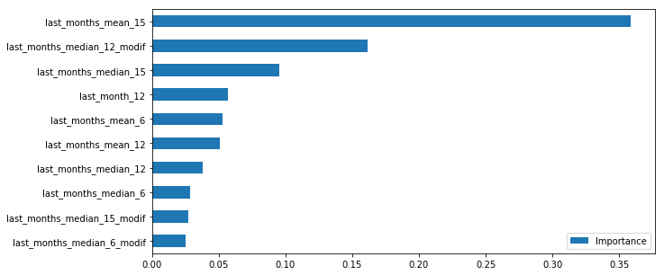

```python
importance_rf1 = pd.DataFrame(rf1.feature_importances_, columns=['Importance'], index = list(X_train.columns))
importance_rf1.sort_values("Importance", ascending=True, inplace=True)
plot = importance_rf1[-10:].plot(kind='barh', figsize=(10, 5))
```

### Optimize the mae

MAE optimization with Scikit learn RF is very slow :

```python
rf2 = RandomForestRegressor(n_estimators=50, min_samples_leaf=10, oob_score=True, n_jobs=7, criterion="mae")
```

```python
%%time
rf2.fit(X=X_train, y=y_train);
```

```
Wall time: 26min 13s
```

```
RandomForestRegressor(bootstrap=True, criterion='mae', max_depth=None,
           max_features='auto', max_leaf_nodes=None,
           min_impurity_decrease=0.0, min_impurity_split=None,
           min_samples_leaf=10, min_samples_split=2,
           min_weight_fraction_leaf=0.0, n_estimators=50, n_jobs=7,
           oob_score=True, random_state=None, verbose=0, warm_start=False)
```

```python
pred_train_rf2 = rf2.predict(X_train)
pred_rf2 = rf2.predict(X_test_local)
```

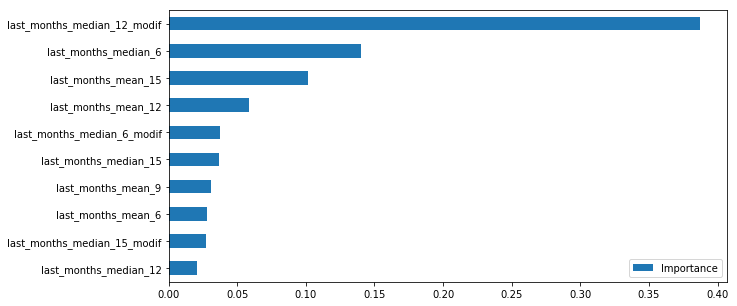

```python
importance_rf2 = pd.DataFrame(rf2.feature_importances_, columns=['Importance'], index = list(X_train.columns))
importance_rf2.sort_values("Importance", ascending=True, inplace=True)
plot = importance_rf2[-10:].plot(kind='barh', figsize=(10, 5))
```

## MAE performances

Random forest (MSE) scores :

```python
print(abs(y_train - pred_train).mean())
print(abs(y_train - rf1.oob_prediction_).mean())
print(abs(y_test_local - pred).mean())
```

```
6.67147482393
8.68515319227
11.2250971178
```

Random forest (MAE) scores :

```python
print(abs(y_train - pred_train_rf2).mean())
print(abs(y_train - rf2.oob_prediction_).mean())
print(abs(y_test_local - pred_rf2).mean())
```

```
7.00795040852
8.08774934918
10.2587840004
```

Logically, RF trained for MAE gives better accuracy than the MSE random forest.

But we can see bellow that taking the median of the demand over the last months outperforms the score obtained with random forest !!!

Scores with the means :

```python
features_mean = ['last_months_mean_3', 'last_months_mean_6', 'last_months_mean_9',
                 'last_months_mean_12', 'last_months_mean_15']
for feat in features_mean:
    print(abs(y_test_local - X_test_local[feat].values).mean())
```

```
10.8523976971
10.8390948737
10.5578423599
10.4464051781
10.5648929569
```

Scores with the medians :

```python
features_median = ['last_months_median_3', 'last_months_median_3_modif', 'last_months_median_6',
                   'last_months_median_6_modif','last_months_median_9', 'last_months_median_9_modif',
                   'last_months_median_12', 'last_months_median_12_modif', 'last_months_median_15',
                   'last_months_median_15_modif']
for feat in features_median:
    print(abs(y_test_local - X_test_local[feat].values).mean())
```

```
10.6611335195
10.7576016134
9.89868393836
9.99661288654
10.1519288448
10.1221170752
9.93618781673
9.9043722205
9.93088737201
9.89291808874
```

The median is better !

What we call `median_i_modif` is a slight modification of the median over the last `i` months : in fact, if a couple SalOrg - Material has less than `i` months of history (we consider that the history of a couple SalOrg-Meterial begins when the demand takes a non zero value for the first time), we take the median over the available history.

We see that this modification leads to better MAE for `nb_last_month` = 9, 12, 15

```python
(X_test_local.last_months_median_12.values != X_test_local.last_months_median_12_modif.values).sum()
```

```
1116
```

```python
# Examples of results
pd.concat([df3[list(range(50,62))],
           X_test_local[["last_months_median_12", "last_months_median_12_modif"]],
           pd.DataFrame({"true_value" : y_test_local})], axis = 1).iloc[[0,1,2,3,4,10,73,86],:]
```

|  | 50 | 51 | 52 | 53 | 54 | 55 | 56 | 57 | 58 | 59 | 60 | 61 | last_months_median_12 | last_months_median_12_modif | true_value |
| --- | --- | --- | --- | --- | --- | --- | --- | --- | --- | --- | --- | --- | --- | --- | --- |
| 0 | 9.0 | 0.0 | 1.0 | 9.0 | 6.0 | 6.0 | 6.0 | 0.0 | 10.0 | 9.0 | 8.0 | 13.0 | 7.0 | 7.0 | 1.0 |
| 1 | 2.0 | 0.0 | 0.0 | 0.0 | 0.0 | 0.0 | 0.0 | 0.0 | 1.0 | 0.0 | 0.0 | 0.0 | 0.0 | 0.0 | 0.0 |
| 2 | 0.0 | 2.0 | 0.0 | 1.0 | 3.0 | 0.0 | 0.0 | 0.0 | 0.0 | 0.0 | 1.0 | 0.0 | 0.0 | 0.0 | 0.0 |
| 3 | 0.0 | 0.0 | 0.0 | 0.0 | 0.0 | 0.0 | 0.0 | 0.0 | 0.0 | 0.0 | 4.0 | 0.0 | 0.0 | 2.0 | 0.0 |
| 4 | 3.0 | 1.0 | 2.0 | 2.0 | 0.0 | 0.0 | 0.0 | 3.0 | 4.0 | 1.0 | 6.0 | 3.0 | 2.0 | 2.0 | 1.0 |
| 10 | 406.0 | 204.0 | 332.0 | 69.0 | 70.0 | 133.0 | 185.0 | 221.0 | 724.0 | 265.0 | 285.0 | 301.0 | 243.0 | 243.0 | 505.0 |
| 73 | 61.0 | 205.0 | 111.0 | 537.0 | 68.0 | 375.0 | 243.0 | 236.0 | 221.0 | 140.0 | 110.0 | 264.0 | 213.0 | 213.0 | 737.0 |
| 86 | 53.0 | 62.0 | 31.0 | 64.0 | 101.0 | 43.0 | 59.0 | 21.0 | 39.0 | 37.0 | 78.0 | 66.0 | 56.0 | 56.0 | 44.0 |

## Optimize the number of last months for the median

The following graphic represents the performances of the median estimator for each month from april 2016 to march 2017.

For each month, we have tested different values for `nb_last_month`: the number of last months over which we take the median.

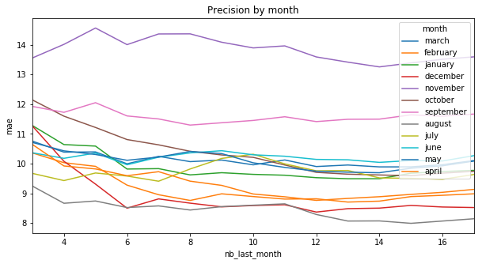

```python
figure, ax = plt.subplots(figsize=(10, 5))
scores.set_index("month").transpose().plot(ax=ax)
ax.set_title("Precision by month")
ax.set_ylabel('mae')
ax.set_xlabel('nb_last_month');
```

Below, the same graphic as before but for april 2016 only :

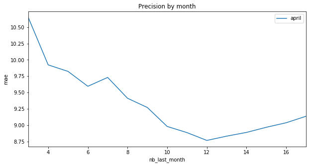

```python
figure, ax = plt.subplots(figsize=(10, 5))
scores.set_index("month").transpose().plot(y="april", ax=ax)
ax.set_title("Precision by month")
ax.set_ylabel('mae')
ax.set_xlabel('nb_last_month');
```

# Assessment of the seasonality and optimization of the model

## Compute the ratios

To take into account the trend and the seasonality, we computed ratios.

The picture bellow gives an example for the month of november. The formula we used to compute the ratio is :

[figure not shown]

We have applied this idea of ratio not on the aggregated serie but on the five series which correspond to each product lines (`PL` variable):

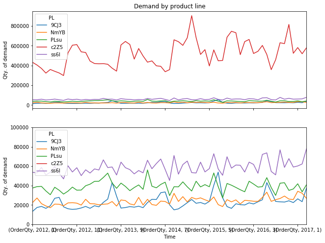

The data below contains all the ratios which correspond to different `PL`, different months and different `nb_last_month` (for the computation of the mean and the median).

```python
data_ratio_PL = make_ratio(df=df, nb_last_month=[3, 6, 9, 12, 15], x_vars_group=["PL"])
data_ratio_PL.head()
```

| PL | r_means_m3_3 | r_means_m3_6 | r_means_m3_9 | r_means_m3_12 | r_means_m3_15 | r_means_m2_3 | r_means_m2_6 | r_means_m2_9 | r_means_m2_12 | r_means_m2_15 | r_means_m1_3 | r_means_m1_6 | r_means_m1_9 | r_means_m1_12 | r_means_m1_15 | r_means_m12_3 | r_means_m12_6 | r_means_m12_9 | r_means_m12_12 | r_means_m12_15 | r_means_m11_3 | r_means_m11_6 | r_means_m11_9 | r_means_m11_12 | r_means_m11_15 | r_means_m10_3 | r_means_m10_6 | r_means_m10_9 | r_means_m10_12 | … |
| --- | --- | --- | --- | --- | --- | --- | --- | --- | --- | --- | --- | --- | --- | --- | --- | --- | --- | --- | --- | --- | --- | --- | --- | --- | --- | --- | --- | --- | --- | --- |
| 9CJ3 | 1.190636 | 1.259514 | 1.038895 | 1.061638 | 1.110599 | 0.986575 | 1.005309 | 0.841624 | 0.876222 | 0.911237 | 1.142782 | 0.954038 | 0.912345 | 0.954782 | 0.995235 | 1.083856 | 0.791829 | 0.830724 | 0.868848 | 0.920671 | 0.998900 | 0.764236 | 0.823402 | 0.874302 | 0.911422 | 0.661827 | 0.669895 | 0.731617 | 0.774313 | … |
| NmYB | 1.000852 | 0.996757 | 1.027447 | 1.047174 | 1.064451 | 0.996903 | 1.018851 | 1.034651 | 1.043565 | 1.057658 | 1.185076 | 1.201328 | 1.207936 | 1.192044 | 1.198118 | 0.872703 | 0.915415 | 0.935021 | 0.934667 | 0.930299 | 1.032525 | 1.045242 | 1.050681 | 1.054143 | 1.062860 | 1.066279 | 1.067738 | 1.045578 | 1.056262 | … |
| PLsu | 1.157570 | 1.145644 | 1.141548 | 1.127496 | 1.113712 | 1.069175 | 1.075561 | 1.033664 | 1.015187 | 0.998932 | 1.000249 | 1.015546 | 0.978790 | 0.967150 | 0.944921 | 0.942353 | 0.942139 | 0.928937 | 0.925074 | 0.931486 | 1.010732 | 0.949785 | 0.932601 | 0.942283 | 0.959487 | 1.081394 | 1.015423 | 1.003045 | 1.003306 | … |
| c2Z5 | 0.845588 | 0.800191 | 0.907698 | 0.949391 | 0.929458 | 0.902696 | 0.956259 | 1.059484 | 1.083512 | 1.065429 | 1.036830 | 1.196024 | 1.270499 | 1.254099 | 1.220744 | 0.836110 | 1.037463 | 1.089861 | 1.013054 | 0.975873 | 1.223241 | 1.396113 | 1.397060 | 1.295921 | 1.289063 | 1.424494 | 1.443524 | 1.359274 | 1.244271 | … |
| ss6l | 1.152616 | 1.103300 | 1.117241 | 1.113352 | 1.143638 | 0.981823 | 0.984430 | 0.964093 | 0.973166 | 0.982537 | 0.958464 | 0.962248 | 0.945838 | 0.953566 | 0.942198 | 0.929288 | 0.966463 | 0.966899 | 0.998590 | 0.995241 | 1.056154 | 1.022358 | 1.038247 | 1.042805 | 1.051607 | 0.971751 | 0.945184 | 0.957552 | 0.959092 | … |

Here is a graphical representation of the ratios for `nb_last_month` = 12 :

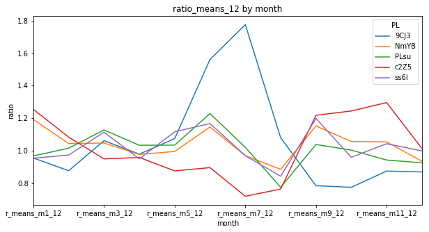

```python
figure, ax = plt.subplots(figsize=(10, 5))
data_ratio_PL[[("r_means_m" + str(j) + "_12") for j in range(1,13)]].transpose().plot(ax=ax)
ax.set_title("ratio_means_12 by month")
ax.set_ylabel('ratio')
ax.set_xlabel('month');
```

## Results for march 2017

Use the ratios computed based on median :

```python
print(abs(y_test_local - X_test_local.last_months_median_6.values * data_PL.r_medians_m3_6).mean())
print(abs(y_test_local - X_test_local.last_months_median_6_modif.values * data_PL.r_medians_m3_6).mean())

print(abs(y_test_local - X_test_local.last_months_median_12.values * data_PL.r_medians_m3_12).mean())
print(abs(y_test_local - X_test_local.last_months_median_12_modif.values * data_PL.r_medians_m3_12).mean())

print(abs(y_test_local - X_test_local.last_months_median_15.values * data_PL.r_medians_m3_15).mean())
print(abs(y_test_local - X_test_local.last_months_median_15_modif.values * data_PL.r_medians_m3_15).mean())
```

```
10.061099984527676
10.190240199426693
9.911761309150673
9.907590285175399
9.976019689541411
9.969431025446273
```

Use the ratios computed based on mean :

```python
print(abs(y_test_local - X_test_local.last_months_median_6.values * data_PL.r_means_m3_6).mean())
print(abs(y_test_local - X_test_local.last_months_median_6_modif.values * data_PL.r_means_m3_6).mean())

print(abs(y_test_local - X_test_local.last_months_median_12.values * data_PL.r_means_m3_12).mean())
print(abs(y_test_local - X_test_local.last_months_median_12_modif.values * data_PL.r_means_m3_12).mean())

print(abs(y_test_local - X_test_local.last_months_median_15.values * data_PL.r_means_m3_15).mean())
print(abs(y_test_local - X_test_local.last_months_median_15_modif.values * data_PL.r_means_m3_15).mean())
```

```
10.04542696812757
10.171992267802466
9.801716137929958
9.787040691239742
9.861587836124302
9.845033985469176
```

In the above results, we see that for the month of march 2017, the ratio adjustment allows to improve the MAE if we consider the ratios computed based on the means.

## Generalization for the other months ?

Unfortunately, that technic based on ratio doesn't always improve the score (for months different than march 2017).

Plot for march 2017 :

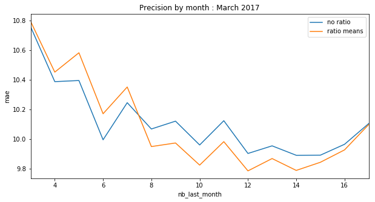

```python
fig, ax = plt.subplots(figsize=(10,5))
scores_median_modif2.set_index("month").transpose().plot(y="march", ax=ax, label='no ratio')
scores_median_modif_ratio_means_PL2.set_index("month").transpose().plot(y="march", ax=ax, label='ratio means')
ax.set_title("Precision by month : March 2017")
ax.set_ylabel('mae')
ax.set_xlabel('nb_last_month')
ax.legend(loc=0);
```

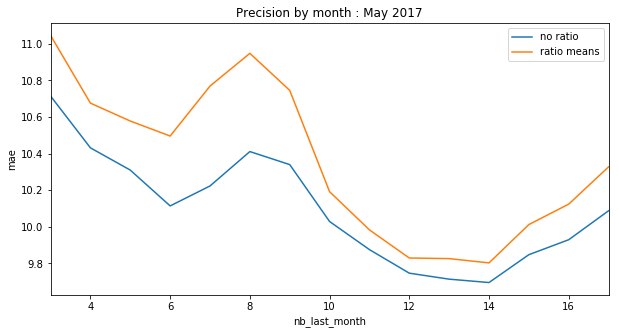

```python
fig, ax = plt.subplots(figsize=(10,5))
scores_median_modif2.set_index("month").transpose().plot(y="may", ax=ax, label='no ratio')
scores_median_modif_ratio_means_PL2.set_index("month").transpose().plot(y="may", ax=ax, label='ratio means')
ax.set_title("Precision by month : May 2017")
ax.set_ylabel('mae')
ax.set_xlabel('nb_last_month')
ax.legend(loc=0);
```

Apparently, the ratio method on the product line doesn't significatively improve the MAE. The same idea can be applied for other features.

# Conclusion

## Final submission

Our submission which scores the best is a mean of 3 submissions :

- median over the last 12 months with modification based on history available (see 2.3)
- two other models where we used the method of the ratio :
  - one where the ratios are computed based on PL
  - one where the ratios are computed based on PL + [low, mid, high] where low/mid/high indicates the order of magnitude of the median : low [0;1[, mid [1,10[, and high [10+]

## What we could have done to improve the score

- Use more variables to train the random forest, because in our approach we use few information
- Other methods to use classical regressor (RF, GBM, etc..) in the context of time series
- Treat separately the items with small order quantity (e.g. < 50) and the items with big order quantity (eg. >= 50). Remark : normalisation in MAE !)
- More sofisticated time series models
  - ARMA
  - ARIMA
- Reason at a different level : `SalOrg/Material/ShipTo` instead of `SalOrg/Material`

View of the data if we reason in terms of `SalOrg/Material/ShipTo`:

```python
df5.loc[((df5.SalOrg == "97LK") & (df5.Material.isin(["03eCyI", "0PpD2L", "0TnOXU"])) ), ].head(10)
```

| year month | SalOrg | Material | Ship_To | OrderQty 2012 1 | OrderQty 2012 2 | OrderQty 2012 3 | OrderQty 2012 4 | OrderQty 2012 5 | OrderQty 2012 6 | OrderQty 2012 7 | OrderQty 2012 8 | OrderQty 2012 9 | OrderQty 2012 10 | OrderQty 2012 11 | OrderQty 2012 12 | OrderQty 2013 1 | OrderQty 2013 2 | OrderQty 2013 3 | OrderQty 2013 4 | OrderQty 2013 5 | OrderQty 2013 6 | OrderQty 2013 7 | OrderQty 2013 8 | OrderQty 2013 9 | OrderQty 2013 10 | OrderQty 2013 11 | OrderQty 2013 12 | OrderQty 2014 1 | OrderQty 2014 2 | … |
| --- | --- | --- | --- | --- | --- | --- | --- | --- | --- | --- | --- | --- | --- | --- | --- | --- | --- | --- | --- | --- | --- | --- | --- | --- | --- | --- | --- | --- | --- | --- |
| 115 | 97LK | 03eCyI | 1fkbED | 0.0 | 0.0 | 0.0 | 0.0 | 0.0 | 0.0 | 0.0 | 0.0 | 0.0 | 0.0 | 0.0 | 0.0 | 0.0 | 0.0 | 0.0 | 0.0 | 0.0 | 0.0 | 0.0 | 0.0 | 0.0 | 0.0 | 0.0 | 0.0 | 0.0 | 0.0 | … |
| 116 | 97LK | 03eCyI | 1ibSnV | 0.0 | 0.0 | 0.0 | 0.0 | 0.0 | 0.0 | 0.0 | 0.0 | 0.0 | 0.0 | 0.0 | 0.0 | 0.0 | 0.0 | 0.0 | 0.0 | 0.0 | 0.0 | 0.0 | 0.0 | 0.0 | 0.0 | 0.0 | 0.0 | 0.0 | 0.0 | … |
| 117 | 97LK | 03eCyI | 1lTMza | 0.0 | 0.0 | 0.0 | 0.0 | 0.0 | 0.0 | 0.0 | 0.0 | 0.0 | 0.0 | 0.0 | 0.0 | 0.0 | 0.0 | 0.0 | 0.0 | 0.0 | 0.0 | 0.0 | 0.0 | 0.0 | 0.0 | 0.0 | 0.0 | 0.0 | 0.0 | … |
| 118 | 97LK | 03eCyI | 2l2fwL | 0.0 | 0.0 | 0.0 | 0.0 | 0.0 | 0.0 | 0.0 | 0.0 | 0.0 | 0.0 | 0.0 | 0.0 | 0.0 | 0.0 | 0.0 | 0.0 | 0.0 | 0.0 | 0.0 | 0.0 | 0.0 | 0.0 | 0.0 | 0.0 | 0.0 | 0.0 | … |
| 119 | 97LK | 03eCyI | 4uYwtq | 0.0 | 0.0 | 0.0 | 0.0 | 0.0 | 0.0 | 0.0 | 0.0 | 10.0 | 0.0 | 0.0 | 0.0 | 0.0 | 10.0 | 0.0 | 0.0 | 0.0 | 0.0 | 0.0 | 0.0 | 10.0 | 0.0 | 0.0 | 0.0 | 0.0 | 0.0 | … |
| 120 | 97LK | 03eCyI | 65QEg9 | 0.0 | 0.0 | 0.0 | 0.0 | 0.0 | 0.0 | 0.0 | 0.0 | 0.0 | 10.0 | 0.0 | 0.0 | 0.0 | 0.0 | 0.0 | 0.0 | 0.0 | 0.0 | 0.0 | 0.0 | 0.0 | 0.0 | 0.0 | 0.0 | 0.0 | 0.0 | … |
| 121 | 97LK | 03eCyI | 6IgBEp | 0.0 | 0.0 | 0.0 | 0.0 | 0.0 | 0.0 | 0.0 | 0.0 | 10.0 | 0.0 | 20.0 | 0.0 | 0.0 | 0.0 | 0.0 | 0.0 | 0.0 | 0.0 | 0.0 | 0.0 | 0.0 | 0.0 | 0.0 | 0.0 | 10.0 | 0.0 | … |
| 122 | 97LK | 03eCyI | 6Thm7v | 0.0 | 0.0 | 0.0 | 0.0 | 0.0 | 0.0 | 0.0 | 0.0 | 0.0 | 0.0 | 0.0 | 0.0 | 0.0 | 0.0 | 5.0 | 0.0 | 3.0 | 0.0 | 0.0 | 0.0 | 0.0 | 0.0 | 0.0 | 0.0 | 0.0 | 0.0 | … |
| 123 | 97LK | 03eCyI | 6gLP2D | 0.0 | 0.0 | 0.0 | 0.0 | 0.0 | 0.0 | 0.0 | 0.0 | 0.0 | 0.0 | 0.0 | 0.0 | 0.0 | 0.0 | 0.0 | 0.0 | 0.0 | 0.0 | 0.0 | 0.0 | 0.0 | 0.0 | 0.0 | 0.0 | 0.0 | 0.0 | … |
| 124 | 97LK | 03eCyI | 6qnNBd | 0.0 | 0.0 | 0.0 | 0.0 | 0.0 | 0.0 | 0.0 | 0.0 | 0.0 | 0.0 | 0.0 | 0.0 | 0.0 | 0.0 | 0.0 | 0.0 | 0.0 | 0.0 | 0.0 | 0.0 | 0.0 | 0.0 | 0.0 | 0.0 | 0.0 | 0.0 | … |

Thank you for your attention !